# 第5章 高级数据管理

武汉大学经济与管理学院  
刘开军 博士  
Email: kjliu@whu.edu.cn

## 高级数据管理

- 常用数学函数
- 常用统计函数
- 常用概率函数
- 常用字符串处理函数
- 其他实用函数
- apply函数簇

## 常用数学函数

| 函数 | 功能 |
| --- | --- |
| abs(x) | x的绝对值 |
| sqrt(x) | x的平方根 |
| ceiling(x) | 向上取整，即不小于x的最小整数，例如ceiling(3.7)结果为4 |
| floor(x) | 向下取整，即不大于x的最大整数，例如floor(3.7)结果为3 |
| trunc(x) | 截断取整，例如trunc(-1.2)结果为-1，floor(-1.2)结果为-2 |
| round(x, digits=n) | 舍入取整。例如，round(5.18, digits=1)结果为5.2 |
| signif(x, digits=n) | 将x舍入成n位有效数字。例如，signif(5.18, digits=2)结果为5.2 |
| sin(x), cos(x), tan(x) | x的正弦，余弦，正切 |
| asin(x), acos(x), atan(x) | x的反正弦，反余弦，反正切 |
| sinh(x), cosh(x), tanh(x) | x的双曲正弦，双曲余弦，双曲正切 |
| log(x, base=n) | x的对数，以n为底数。如果省略参数`base`，则取自然对数 |
| log(x), log10(x) | x的自然对数，常用对数 |
| exp(x) | x的自然指数。例如，exp(5)即e^5，结果为148.4131591 |

以上函数中的x可以是标量，也可以是向量、矩阵、数据框。

```r
sqrt(2)
```

```
## [1] 1.414214
```

```r
sqrt(c(2, 3, 8, 10))
```

```
## [1] 1.414214 1.732051 2.828427 3.162278
```

```r
sqrt(matrix(1:20, nrow=4))
```

```
##          [,1]     [,2]     [,3]     [,4]     [,5]
## [1,] 1.000000 2.236068 3.000000 3.605551 4.123106
## [2,] 1.414214 2.449490 3.162278 3.741657 4.242641
## [3,] 1.732051 2.645751 3.316625 3.872983 4.358899
## [4,] 2.000000 2.828427 3.464102 4.000000 4.472136
```

通常情况下，将对标量定义的函数应用到向量（或其他组合型数据）时，结果是将该函数应用到向量的每个元素上，这种运算被称为**向量化**。R自带的函数大部分都支持向量化，例如上面的数学函数sqrt()。

## 常用统计函数

| 函数 | 功能 |
| --- | --- |
| length(x) | x的长度 |
| mean(x) | 平均值 |
| median(x) | 中位数 |
| sd(x) | 标准差 |
| var(x) | 方差 |
| mad(x) | 平均绝对偏差 |
| quantile(x, prob) | 求样本x的分位点 |
| range(x) | 求样本x的值域 |
| sum(x) | 求和 |
| diff(x, lag=n) | 求滞后n步的差分，默认lag=1 |
| min(x) | 求最小值 |
| max(x) | 求最大值 |
| scale(x, center=TRUE, scale=TRUE) | 将样本x标准化 |

以上统计函数通常带有可选参数，若要精确控制计算结果，有时需要使用这些参数。例如：

```r
x <- rnorm(1000)    #随机生成1000个服从标准正态分布的点
mean(x, trim=0.05)  #去掉样本x中最大和最小的5%数据，再计算平均值
```

```
## [1] 0.03022078
```

```r
min(x); max(x)
```

```
## [1] -3.385767
```

```
## [1] 2.86881
```

```r
quantile(x, c(0, 0.25, 0.5, 0.75, 1))   #计算最小值和最大值，以及各四分位点
```

```
##          0%         25%         50%         75%        100%
## -3.38576702 -0.61958936  0.02497061  0.66493837  2.86880958
```

```r
a <- quantile(x, c(0, 0.25, 0.5, 0.75, 1))  #a是一个向量
names(a)
```

```
## [1] "0%"   "25%"  "50%"  "75%"  "100%"
```

```r
a[3]    #单独获取中位点数据
```

```
##        50%
## 0.02497061
```

**函数`scale()`**

函数`scale()`用于将样本数据标准化，是进行样本分析时最常用的预处理方法之一。标准化是指将一个样本转换成均值为0、方差为1的新样本。

对于样本$X=(x_1, x_2, \cdots, x_n)$，记样本$X$的均值为$\mu$、标准差为$\sigma$，标准化后的新样本为$Y=(y_1, y_2, \cdots, y_n)$，则两个样本之间的换算公式为：

$$y_k = \frac{x_k - \mu}{\sigma}$$

函数`scale()`的原型为：

newdata <- scale(mydata, center=TRUE, scale=TRUE)

其中，参数`center`表示在标准化时是否要将均值化为0，默认为TRUE；参数`scale`表示在标准化时是否要将标准差化为1，默认为TRUE。

## 常用概率函数

概率函数的函数名为：

> [d p q r]DistributionName(…)

其中, 第一个字母`d p q r`表示函数的功能：

- d 表示密度函数(density)
- p 表示累计分布函数(probility)
- q 表示分位点函数(quantile)，即累计分布函数的逆函数
- r 表示生成随机数(random)

后面的`DistributionName`是概率分布的名字，可以是：

| DistrubtionName | 说明 | DistributionName | 说明 |
| --- | --- | --- | --- |
| beta | Beta分布 | logis | Logistic分布 |
| binom | 二项分布 | multinom | 多项分布 |
| cauchy | Cauchy分布 | nbinom | 负二项分布 |
| chisq | 卡方分布 | **norm** | 正态分布 |
| exp | 指数分布 | pois | 泊松分布 |
| f | F分布 | signrank | Wilcoxon符号秩分布 |
| gamma | Gamma分布 | t | t分布 |
| geom | 几何分布 | **unif** | 均匀分布 |
| hyper | 超几何分布 | weibull | Weibull分布 |
| lnorm | 对数正态分布 | wilcox | Wilcoxon秩和分布 |

例如，`rnorm()`表示生成服从正态分布的随机数。最后，每个概率分布函数都有若干参数，用来指定概率分布的参数。

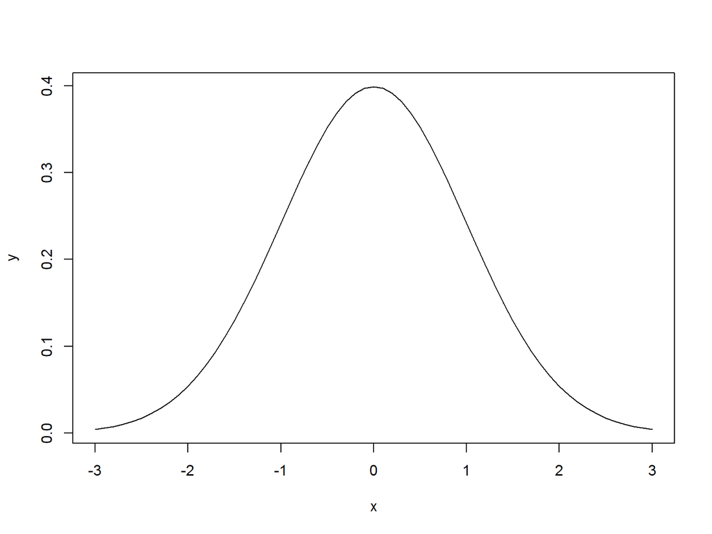

```r
x <- seq(-3, 3, 0.1)  # -3.0, -2.9, -2.8, ..., 2.9, 3.0
y <- dnorm(x)
plot(x, y, type="l")
```

**正态分布和均匀分布**

正态分布的概率函数带有两个参数：`mean`指定正态分布的均值，默认为0；`sd`指定正态分布的标准差，默认为1。例如：

```r
a <- rnorm(100, mean=10, sd=3)  #从正态分布N(10, 3^2)随机抽取100个点
mean(a)   #这100个点的平均值应该接近10
```

```
## [1] 10.02594
```

均匀分布的概率函数也带有两个参数：`min`指定分布的最小值，默认为0；`max`指定分布的最大值，默认为1。例如：

```r
a <- runif(100, min=1, max=5)   # a~U[1, 5]
mean(a)   #should be about 3
```

```
## [1] 3.073209
```

## 常用字符串处理函数

| 函数 | 功能 |
| --- | --- |
| nchar(x) | 计算x的字符数。例如 nchar(“abc”)结果为3 |
| substr(x, start, stop) | 提取或替换字符串的子串。例如，`substr(“abcde”, 2, 4)`结果为“bcd”；`substr(x, 2, 4) <- “BCD”`将把x的2:4子串替换为“BCD” |
| grep(pattern, x, ignore.case=FALSE, fixed=FALSE) | 在字符串向量x中搜索子串pattern。fixed=TRUE表示pattern是一个普通字符串，fixed=FALSE表示pattern是一个正则表达式 |
| sub(pattern, replacement, x, ignore.case=FALSE, fixed=FALSE) | 在字符串向量x中搜索pattern，并以replacement替换。对x的每个元素，只将第1个pattern替换为replacement，即对x的每个元素最多执行一次替换 |
| gsub(pattern, replacement, x, ignore.case=FALSE, fixed=FALSE) | 在字符串向量x中搜索pattern，并以replacement替换。对x的每个元素，将所有的pattern都用replacement替换掉 |
| strsplit(x, split, fixed=FALSE) | 用split作为分隔字符，把字符串向量x中的每个元素分成若干段 |
| paste(…, sep=`" "`, collapse=NULL) | 将多个字符串连接成一个长字符串 |
| toupper(x), tolower(x) | 将x转换为大写、小写 |

字符串函数示例

```r
nchar("abcde")  #计算一个字符串的长度
## [1] 5

a <- c("Apple", "Microsoft", "Lenovo", "Alibaba")
nchar(a)   #类似于sqrt()、sin()等函数，nchar()也支持向量化
## [1] 5 9 6 7

length(a)  #计算一个向量的长度
## [1] 4

a <- "abcde"
substr(a, 2, 4)   #提取字符串的一部分
## [1] "bcd"

substr(a, 2, 4) <- "BCD"    #替换子串
a
## [1] "aBCDe"

toupper("aBc")  #全部转换成大写
## [1] "ABC"

toupper(c("abc", "def", "ghi"))   #支持向量化
## [1] "ABC" "DEF" "GHI"

tolower("ABc")  #全部转换成小写
## [1] "abc"
```

字符串查找

grep(pattern, x, ignore.case=FALSE, fixed=FALSE)

其功能是在字符串向量x中搜索子串pattern。参数ignore.case表示是否忽略字母大小写，默认值为FALSE，表示在搜索时要区分大小写。参数fixed表示pattern的类型，fixed=TRUE表示pattern是一个普通字符串，fixed=FALSE表示pattern是一个正则表达式。正则表达式可以理解为一种字符串模板，借助正则表达式可以完成比较复杂的搜索，我们在后面章节介绍。

若pattern是一个由英文字母、数字组成的字符串，fixed取TRUE或FALSE的结果相同。

`grep()`会依次检查向量x的每个元素，若能够匹配pattern，则将其下标记录下来。`grep()`的返回值是这些下标组成的向量。

```r
workmates <- c("ZhangSanBao", "ZhangHui", "LiuSanWen", "ChensanMing")
grep("San", workmates)  #得到含有San的字符串的下标
```

```
## [1] 1 3
```

```r
grep("san", workmates, ignore.case=TRUE)  #忽略大小写
```

```
## [1] 1 3 4
```

```r
grep("Zhang.*Bao", workmates)  #使用正则表达式，.*可以匹配任意个任意字符
```

```
## [1] 1
```

```r
workmates[ grep("San", workmates) ]  #得到含有San的字符串
```

```
## [1] "ZhangSanBao" "LiuSanWen"
```

DIY: `grep()`函数还有一个参数value，它可以控制函数返回值的类型。value=FALSE（默认值）表示函数的返回值是下标组成的向量，value=TRUE表示返回值是字符串组成的向量。

```r
workmates <- c("ZhangSanBao", "ZhangHui", "LiuSanWen", "ChensanMing")
workmates[ grep("San", workmates) ]
```

```
## [1] "ZhangSanBao" "LiuSanWen"
```

```r
grep("San", workmates, value=TRUE)  #使用value=TRUE完成相同功能
```

```
## [1] "ZhangSanBao" "LiuSanWen"
```

字符串替换使用`sub()`或`gsub()`，前者仅完成一次替换，后者会进行多次替换。

```r
friends <- c("WangHong", "ZhangPing", "WangWangSan")
sub("Wang", "Liu", friends)    #将Wang替换为Liu，对每个字符串最多替换一次
```

```
## [1] "LiuHong"    "ZhangPing"  "LiuWangSan"
```

```r
gsub("Wang", "Liu", friends)   #对每个字符串进行完全替换
```

```
## [1] "LiuHong"   "ZhangPing" "LiuLiuSan"
```

字符串拼接

字符串拼接函数为`paste()`，其语法为：

paste(x<sub>1</sub>, x<sub>2</sub>, …, x<sub>k</sub>, sep=`" "`, collapse=NULL)

该函数的参数有两种可能：

- 若x<sub>1</sub>,…,x<sub>k</sub>都是字符串，那么paste()将把这些字符串连接成一个长字符串，各字符串之间用参数sep的值作为分隔符。`paste()`的返回值为拼接所得的长字符串。
- 若x<sub>1</sub>,…,x<sub>k</sub>都是字符串向量，那么paste()会执行以下操作：取x<sub>1</sub>至x<sub>k</sub>的第1个元素，用参数sep的值作为分隔符连接成一个子字符串；再取x<sub>1</sub>至x<sub>k</sub>的第2个元素，用参数sep的值作为分隔符连接成一个子字符串；依次执行此操作，最后再将这些子字符串组成一个向量作为`paste()`的返回值。但是，如果指定了参数collapse为非NULL，那么最后会将各子字符串用参数collapse的值作为分隔符连接成一个长字符串，`paste()`的返回值为拼接所得的长字符串。

参数sep的默认值是空格，参数collapse的默认值是NULL。`paste()`的返回值为拼接所得的长字符串。

```r
paste("Hello", "World")   #连接两个字符串
## [1] "Hello World"

paste("Hello", "World", sep="-")   #使用参数sep指定拼接时的间隔符
## [1] "Hello-World"

paste(c("Mr", "Dr", "Prof"), c("Gates", "Cai", "Liu"), sep=". ")  #将两个向量的各元素对应拼接
## [1] "Mr. Gates" "Dr. Cai"   "Prof. Liu"

paste(c("A", "B", "C"), c("a", "b", "c"), sep="-", collapse=", ")  #连接成一个长字符串
## [1] "A-a, B-b, C-c"

paste(c("Hello", "world"), collapse=" ")  #将一个字符串向量合并成一个长字符串
## [1] "Hello world"

paste(c("A", "B", "C"), c(1:3), sep="-")  #必要时，paste会先将参数转换为字符串
## [1] "A-1" "B-2" "C-3"
```

函数`paste()`在必要时会使用循环补齐规则。

```r
mystr <- paste("Hello", c("Mr. Gates", "Dr. Cai", "Prof. Liu"), sep=", ", collapse="\n")
cat(mystr)
```

```
## Hello, Mr. Gates
## Hello, Dr. Cai
## Hello, Prof. Liu
```

字符串的拆分

字符串拆分函数`strsplit()`

```r
mynames <- c("Bill Gates", "Warren M. Buffett", "Donald Trump")
ret <- strsplit(mynames, " ")  #把每个人名分解成姓和名两部分
ret
## [[1]]
## [1] "Bill"  "Gates"
##
## [[2]]
## [1] "Warren"  "M."      "Buffett"
##
## [[3]]
## [1] "Donald" "Trump"
```

## 其他实用函数

| 函数 | 功能 |
| --- | --- |
| length(x) | 求向量或列表x的长度 |
| str(x) | 查看对象x的结构(structure) |
| seq(from, to, by) | 生成一个等差数列，从from值开始，至to值终止，步长为by |
| seq_along(x) | 生成一个向量1:length(x) |
| rep(x, times=1, each=1) | 先将向量x的每个元素重复each次，再将所得向量重复times次。 |
| pretty(x, n) | 将向量x指定的区间分成n等份，通常在绘图时使用此函数创建横坐标值 |
| cut(x, n) | 将连续变量x分割为有n个水平的因子 |
| cat(…, sep=`" "`) | 将各参数连接(concatenate)成一个字符串，打印到屏幕上。连接时的分隔符为sep。该函数在输出完字符串后，不会另起一行。该函数没有返回值。`"\n"`表示换行符，即另起一行 |
| print(x) | 将x转换成字符串，打印到屏幕上。该函数会根据参数x的类型，调用适当的转换函数。该函数在输出完字符串后，会自动另起一行。该函数的返回值是x |

例如：

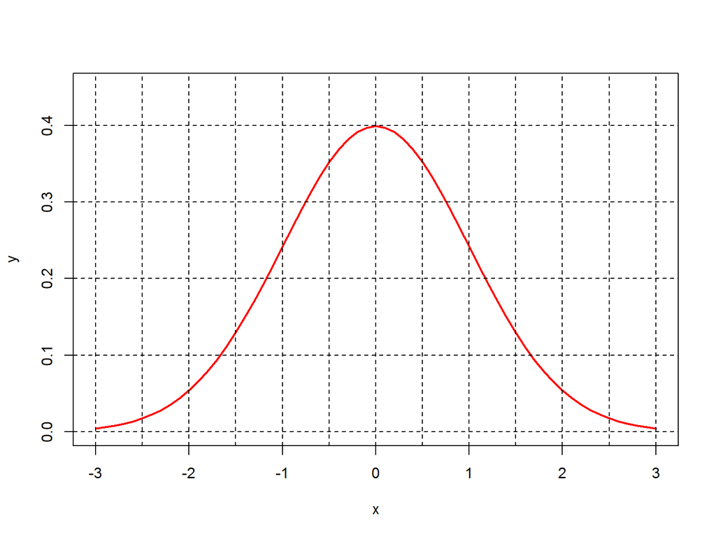

```r
str(mtcars)
## 'data.frame':    32 obs. of  11 variables:
##  $ mpg : num  21 21 22.8 21.4 18.7 18.1 14.3 24.4 22.8 19.2 ...
##  $ cyl : num  6 6 4 6 8 6 8 4 4 6 ...
##  $ disp: num  160 160 108 258 360 ...
##  $ hp  : num  110 110 93 110 175 105 245 62 95 123 ...
##  $ drat: num  3.9 3.9 3.85 3.08 3.15 2.76 3.21 3.69 3.92 3.92 ...
##  $ wt  : num  2.62 2.88 2.32 3.21 3.44 ...
##  $ qsec: num  16.5 17 18.6 19.4 17 ...
##  $ vs  : num  0 0 1 1 0 1 0 1 1 1 ...
##  $ am  : num  1 1 1 0 0 0 0 0 0 0 ...
##  $ gear: num  4 4 4 3 3 3 3 4 4 4 ...
##  $ carb: num  4 4 1 1 2 1 4 2 2 4 ...

seq(from=0, to=3, by=0.2)   #seq()的经典用法。从from开始，步长为by，最大不超过to
##  [1] 0.0 0.2 0.4 0.6 0.8 1.0 1.2 1.4 1.6 1.8 2.0 2.2 2.4 2.6 2.8 3.0

seq(0, 3, 0.2)   #简写形式
##  [1] 0.0 0.2 0.4 0.6 0.8 1.0 1.2 1.4 1.6 1.8 2.0 2.2 2.4 2.6 2.8 3.0

seq(from=0, to=3, length=10)  #从from开始，至to终止，生成length个点
##  [1] 0.0000000 0.3333333 0.6666667 1.0000000 1.3333333 1.6666667 2.0000000
##  [8] 2.3333333 2.6666667 3.0000000

seq(from=0, by=0.2, length=10)   #从from开始，步长为by，生成length个点
##  [1] 0.0 0.2 0.4 0.6 0.8 1.0 1.2 1.4 1.6 1.8

a <- c(10, 3, 5);  seq_along(a)
## [1] 1 2 3

a <- c(); seq_along(a)  #若a是一个空的vector或list，那么seq_along生成一个空的vector
## integer(0)

x <- seq(-3, 3, 0.1); y <- dnorm(x, mean=0, sd=1)
plot(x, y, type="l", lwd=2, col="red", xlim=c(-3, 3), ylim=c(0, 0.45))
abline(v=seq(-3, 3, 0.5), h=seq(0, 0.5, 0.1), lty=2)
```

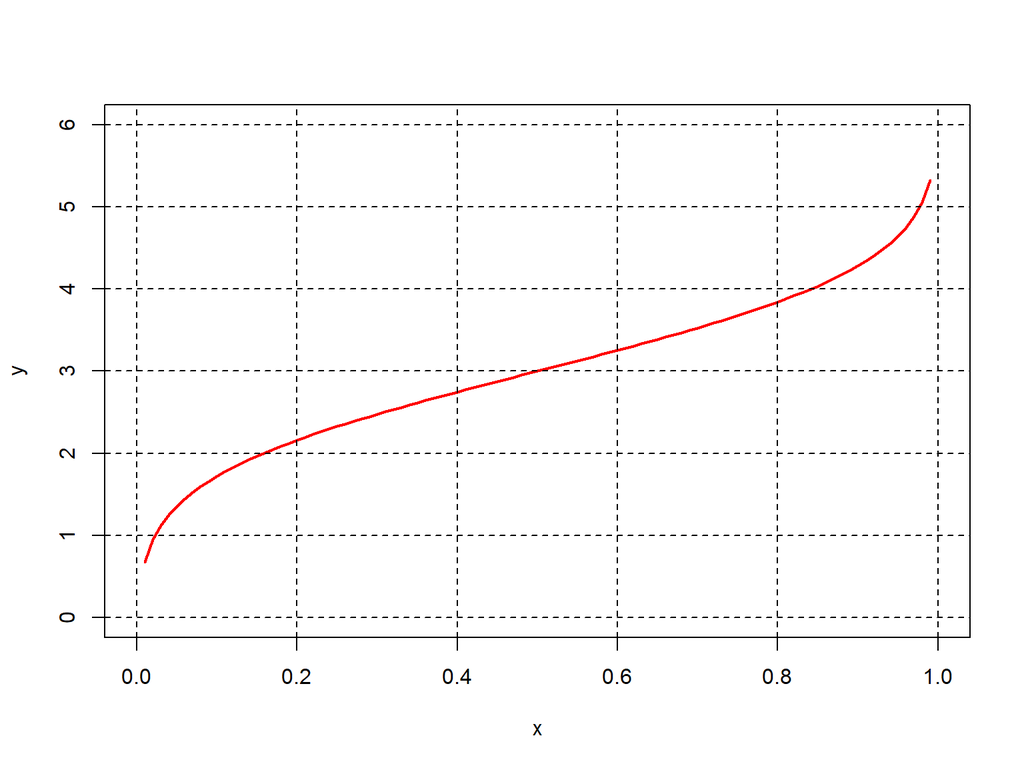

```r
x <- pretty(c(0, 1), 100);  y <- qnorm(x, mean=3, sd=1)
plot(x, y, type="l", lwd=2, col="red", xlim=c(0, 1), ylim=c(0, 6))
abline(v=seq(0, 1, 0.2), h=0:6, lty=2)
```

```r
rep(c(2, 3, 5), 3)    #将c(2,3,5)重复3次，也可写为rep(c(2,3,5), times=3)
## [1] 2 3 5 2 3 5 2 3 5

rep(c(2, 3, 5), times=3, each=2)   #先将c(2,3,5)每个元素重复each次，再将所得向量重复times次
##  [1] 2 2 3 3 5 5 2 2 3 3 5 5 2 2 3 3 5 5

cat("Today is", format(Sys.Date(), "%Y-%m-%d"))   #用cat()输出多个字符串
## Today is 2020-06-14

mybirthday <- as.Date("2020-01-01")
cat(mybirthday)   #2020-01-01距离1970-01-01为18262天
## 18262

print(mybirthday)
## [1] "2020-01-01"

mydata <- factor(c("middle", "low", "middle", "high"), levels=c("low", "middle", "high"))
cat(mydata[1])  # as.numeric(mydata[1]) also gives 2
## 2

print(mydata[1])
## [1] middle
## Levels: low middle high

cat("This is the first line", "\n", "This is the second line\nThis is the third line", sep="")
## This is the first line
## This is the second line
## This is the third line
```

## apply函数簇

这一簇的函数可以将一个函数分别应用到向量（或列表）上，是进行向量化计算的基础。常用的有`apply()`、`lapply()`、`sapply()`和`tapply()`。

函数`apply()`可以将一个函数应用到**二维或高维**数据（矩阵、数据框、数组）的指定维度上去，语法为：

result <- apply(x, MARGIN, FUN, …)

其中，`x`是一个矩阵、数据框或数组；`MARGIN`指定了维度的下标；`FUN`是要使用的函数，该函数以从x中提取的向量作为第1个参数，以“`...`”中的参数作为后续的参数。`apply()`的返回值由`FUN`在各维度上的计算结果组成。

对于二维的矩阵或数据框来说，`MARGIN=1`表示逐行计算，`MARGIN=2`表示逐列计算。

```r
mydata <- matrix(rnorm(400), nrow=5)
apply(mydata, 1, mean)    #计算每行的平均值
```

```
## [1]  0.0011347954 -0.0769477986 -0.0421108362 -0.0006114931  0.0262245907
```

```r
apply(mydata, 1, mean, trim=0.1)   #计算每行的平均值，计算时去掉每行最大和最小的10%数据
```

```
## [1]  0.005916803 -0.045381668 -0.054552397 -0.032663144  0.011915566
```

函数`lapply()`可以将一个函数应用到**一维**数据（向量或列表）的每个元素上，语法是：

result <- lapply(x, FUN, …)

其中，`x`是一个向量或列表，函数`FUN`将被依次应用到`x`的每个元素上。`lapply()`每次从`x`中取出一个元素，作为函数`FUN`的第1个参数，把“`...`”作为函数`FUN`的后续参数，`FUN()`的计算结果会放入result。`lapply()`返回一个与`x`等长的列表。

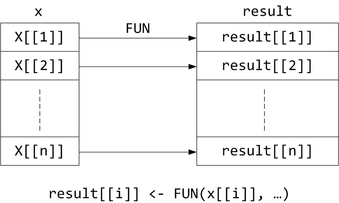

```r
workmates <- c("Liu", "Zhang", "Chen")
lapply(workmates, toupper)
```

```
## [[1]]
## [1] "LIU"
##
## [[2]]
## [1] "ZHANG"
##
## [[3]]
## [1] "CHEN"
```

```r
mylist <- list( 1:10, seq(0, 10, 0.1), pretty(c(0, 10), 100) )
lapply(mylist, length)
```

```
## [[1]]
## [1] 10
##
## [[2]]
## [1] 101
##
## [[3]]
## [1] 101
```

```r
mylist <- list( rnorm(1000), runif(1000), rexp(1000) )
lapply(mylist, range)
```

```
## [[1]]
## [1] -3.027310  2.945553
##
## [[2]]
## [1] 0.0016320 0.9995756
##
## [[3]]
## [1] 0.0004415833 6.8474769421
```

```r
result <- lapply(mylist, quantile, seq(0, 1, 0.25))
cat("N(0,1)的各分位点是：", result[[1]])  #result[[1]]==quantile(rnorm(1000), seq(0, 1, 0.25))
```

```
## N(0,1)的各分位点是： -3.02731 -0.7253339 -0.03822956 0.5826095 2.945553
```

```r
cat("U(0,1)的各分位点是：", result[[2]])  #result[[2]]==quantile(runif(1000), seq(0, 1, 0.25))
```

```
## U(0,1)的各分位点是： 0.001632 0.2319434 0.4845707 0.7276236 0.9995756
```

函数`sapply()`的功能与`lapply()`相似，但`sapply()`会尽量简化(simplify)计算结果，返回值可能是vector、matrix、array。对比：

```r
mylist <- list(1:10, seq(0, 10, 0.1), pretty(c(0, 10), 100))

lapply(mylist, length)  #lapply()总是返回一个list
## [[1]]
## [1] 10
##
## [[2]]
## [1] 101
##
## [[3]]
## [1] 101

sapply(mylist, length)  #返回值是一个vector
## [1]  10 101 101
```

```r
x <- list(rnorm(100), rnorm(120), rnorm(150), rnorm(200))

lapply(x, range)  #返回值是一个list
## [[1]]
## [1] -2.179479  2.264452
##
## [[2]]
## [1] -2.347547  2.956131
##
## [[3]]
## [1] -2.441196  2.103593
##
## [[4]]
## [1] -3.141600  3.443198

sapply(x, range)  #返回值是一个matrix
##           [,1]      [,2]      [,3]      [,4]
## [1,] -2.179479 -2.347547 -2.441196 -3.141600
## [2,]  2.264452  2.956131  2.103593  3.443198
```

DIY: vapply()

sapply()和vapply()都是基于lapply()，sapply()和vapply()都会设法简化lapply()的计算结果，但vapply()还需要指定计算结果的数据类型模板。vapply()其实是对sapply()加了一层数据验证(validation)，vapply()更为安全。

在`vapply(x, FUN, FUN.VALUE, ...)`中，`FUN.VALUE`是一个数据类型模板，`FUN(x[[i]])`的返回值应当与此模板相一致。必要时，vapply()会进行数据类型转换。

```r
data <- list(x=rnorm(100), y=rnorm(120), z=rnorm(200))
vapply(data, range, numeric(2))  #要求每个range(data[[i]])返回2个numeric
##              x         y         z
## [1,] -1.792228 -3.056029 -2.971000
## [2,]  2.692174  2.144731  2.530921

data <- list(x=rnorm(100), y=c("Liu", "Zhang"), z=c(TRUE, FALSE))
vapply(data, mode, character(1))  #要求每个mode(data[[i]])返回1个character
##           x           y           z
##   "numeric" "character"   "logical"

vapply(data, length, integer(1)) #要求每个length(data[[i]])返回1个integer
##   x   y   z
## 100   2   2

vapply(data, length, numeric(1)) #要求每个length(data[[i]])返回1个numeric，此处vapply会做数据类型转换
##   x   y   z
## 100   2   2
```

```r
data <- list(x=rnorm(100), y=rnorm(120), z=rnorm(200))
vapply(data, range, numeric(3))  #Error，模板错误
```

函数`tapply()`是根据若干个向量进行分组，对另一个向量进行统计。`tapply()`的处理方式类似于列联表(table)，因此被称为table-apply。

```r
year <- rep(c(2007, 2008, 2009), times=4)
province <- rep(c("A", "B", "C", "D"), each=3)
sale <- 1:12

tapply(sale, list(year, province), mean)  #根据year和province分组，生成一个matrix
##      A B C  D
## 2007 1 4 7 10
## 2008 2 5 8 11
## 2009 3 6 9 12

tapply(sale, year, mean)  #根据year分组，生成一个array
## 2007 2008 2009
##  5.5  6.5  7.5

tapply(sale, year, mean, trim=0.4)  #mean(x, trim=0.4)
## 2007 2008 2009
##  5.5  6.5  7.5

tapply(sale, year, mean, simplify=FALSE)  #不简化计算结果，本例会生成一个list
## $`2007`
## [1] 5.5
##
## $`2008`
## [1] 6.5
##
## $`2009`
## [1] 7.5
```

`tapply()`的完整语法：

result <- tapply(x, INDEX, FUN, …, default=NA, simplify=TRUE)

其中，x通常是一个向量；INDEX用于指定分组依据，可以是一个向量（单一分组）或若干个向量组成的列表（多重分组），tapply()会将各分组向量转换成factor再使用。

```r
year <- c(2007, 2008, 2007, 2009)
province <- c("A", "B", "C", "A")
sale <- 1:4

tapply(sale, list(year, province), sum)
##       A  B  C
## 2007  1 NA  3
## 2008 NA  2 NA
## 2009  4 NA NA

tapply(sale, list(year, province), sum, default=0)  #将缺失值记为0
##      A B C
## 2007 1 0 3
## 2008 0 2 0
## 2009 4 0 0
```

**下标函数**

在`apply`类函数中，除了可以使用普通函数（例如sqrt）之外，还经常会用到下标函数。下标函数的名字是`[`，其第1个参数是向量、矩阵、列表、数据框等可取下标的变量，其第2个参数是下标值。例如：

```r
mynames <- c("Bill Gates", "Warren Buffett", "Donald Trump")
ret <- strsplit(mynames, " ")  #把每个人名分解成姓和名两部分
firstnames <- sapply(ret, "[", 1)
firstnames
```

```
## [1] "Bill"   "Warren" "Donald"
```

```r
secondnames <- sapply(ret, "[", 2)
secondnames
```

```
## [1] "Gates"   "Buffett" "Trump"
```